# Part II - Teachers' and parents' impact on well-being and success of students in PISA study 2012

## by Philipp Nockemann

## Investigation Overview

- My goal in this slide show is to get some insight into which parental, emotional and teacheral circumstances impact student's success in terms of final weight in PISA 2012 study.
- I chose four visualizations for this slide show, which will lead to some key insights as follows:
  - Visualization 1 - Parental background and success
  - Visualization 2 - Sense of belonging and success
  - Visualization 3 - Follow up: Teacher's behaviour and sense of belonging
  - Visualization 4 - Student-teacher-relationship and success by sense of belonging ranges.

## Dataset Overview

This investigated dataset is the result of PISA study. This study examines how well students have learned the school curriculum, how well prepared they are for life beyond school. Around 510,000 students in 65 economies took part in the PISA 2012 assessment of reading, mathematics and science. Of those economies, 44 took part in an assessment of creative problem solving and 18 in an assessment of financial literacy.

## Visualization 1 - Parental background and success

- In the first visualization, i want to take a look at the relation between final student weights in PISA 2012 study and parents' highest schooling graduation and their current job status respectively.
- We can observe something surprising here: the higher the schooling the worse the results.
- Also we can see that having parents working full-time or parents looking for a job are not the best of circumstances for PISA success.
- I want to share especially the latter insight because we can learn about the importance of parents' support at home!

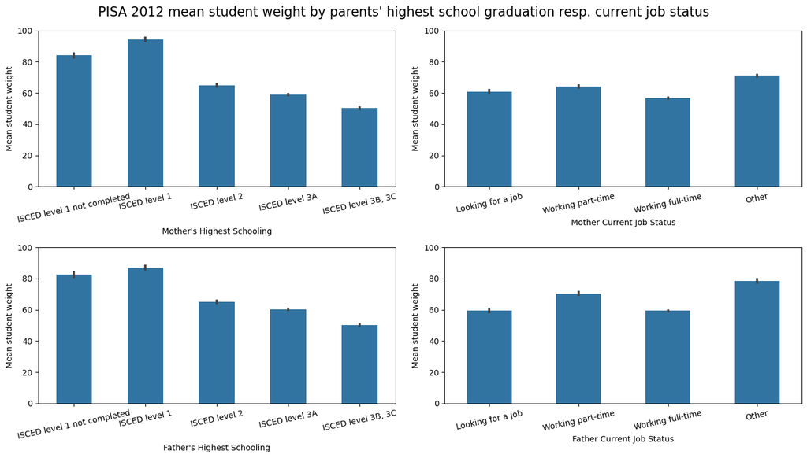

One explanation might be that there are a lot more students with highly graduated parents. The mean weights of students with low graduated parents might thus be pushed by outliers. In fact when playing aroung with ranges of student weight we accept to observe, the picture can vary, but not too much.

## Visualization 2 - Sense of belonging and success

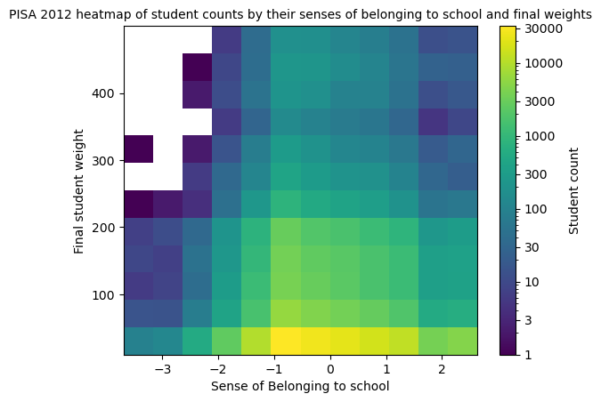

One more note: The many bad results should not worry us at this point. I guess that this is a matter of study execution.